# Homework 11: Clustering

STAT 432 · Python analysis

All numerical analysis and figures were produced with Python. Questions 1 and 2 use the NumPy implementation of K-means below; no existing K-means routine is called. Question 3 uses SciPy’s hierarchical clustering functions. Cluster labels are displayed as **1 through K** in the report; the code uses indices **0 through K−1**.

## Question 1: Implementing K-means

### (a) One iteration

I generated ten observations with two independent standard normal coordinates using **NumPy `default_rng(43211)`**. For the initial assignment in part (a), I used **seed 11**. To ensure nonempty clusters, the label generator reserves one observation for each cluster, assigns random labels to the remaining observations, and randomly permutes all labels. This is a random nonempty assignment; uniform sampling over all nonempty partitions is not required.

```python
x = np.random.default_rng(43211).standard_normal((10, 2))
initial_a = random_nonempty_labels(10, 2, seed=11)
first_means = update_means(x, initial_a, 2)
first_labels = nearest_labels(x, first_means)
```

The cluster means computed from the **initial assignments**, before reassignment, are:

| Cluster | Mean x1 | Mean x2 |
| --- | --- | --- |
| 1 | 0.128574 | -0.088632 |
| 2 | -0.153210 | 0.219205 |

I assigned each observation to the nearest of these two means using Euclidean distance. The following table reports the generated observations and all assignments requested in parts (a) and (c):

| Observation | x1 | x2 | Initial A | After one iteration | Final A | Initial B | Final B |
| --- | --- | --- | --- | --- | --- | --- | --- |
| 1 | 0.427667 | -0.603915 | 1 | 1 | 1 | 1 | 2 |
| 2 | 0.492762 | 0.989512 | 2 | 2 | 2 | 1 | 1 |
| 3 | 1.074375 | -0.960302 | 2 | 1 | 1 | 2 | 2 |
| 4 | -0.986830 | -0.922588 | 1 | 1 | 1 | 2 | 2 |
| 5 | -0.831495 | 1.180844 | 2 | 2 | 2 | 2 | 1 |
| 6 | 1.509960 | 0.195426 | 1 | 1 | 1 | 2 | 2 |
| 7 | -0.655494 | -0.834021 | 2 | 1 | 1 | 2 | 2 |
| 8 | -0.926314 | 1.398656 | 1 | 2 | 2 | 1 | 1 |
| 9 | 0.618386 | -0.510738 | 1 | 1 | 1 | 1 | 2 |
| 10 | -0.846198 | 0.719991 | 2 | 2 | 2 | 2 | 1 |

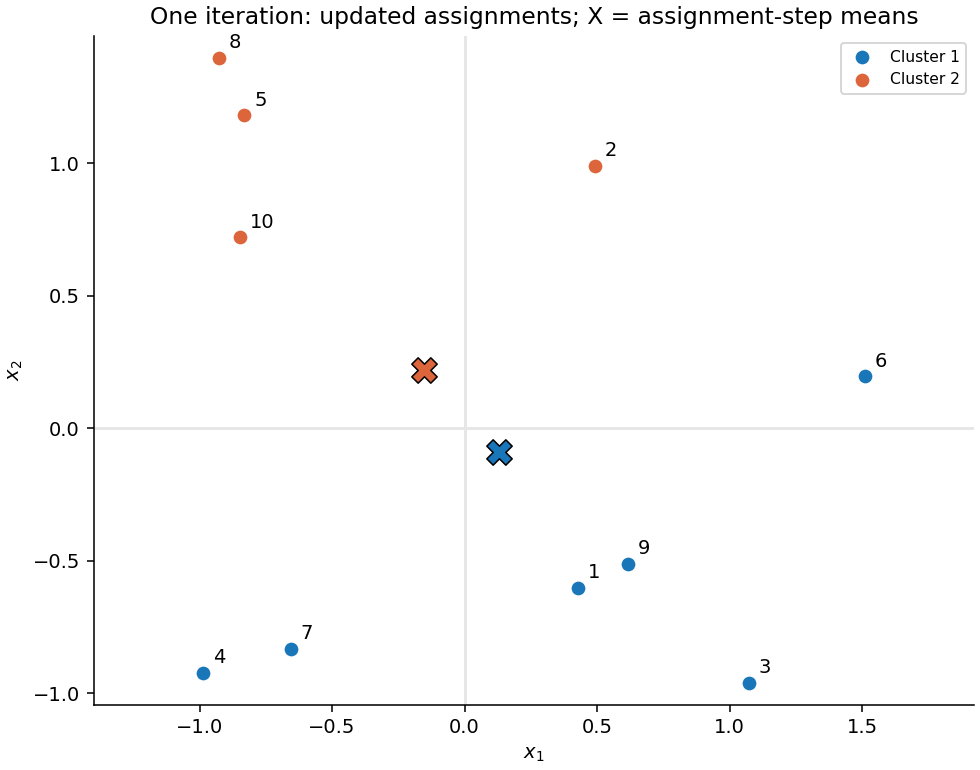

Observations colored by their updated assignments after one iteration. Numbers identify observations. The X markers are the means computed from the initial assignments and used for this reassignment step.

### (b) General K-means function

For each iteration, I compute cluster means and then assign each observation to its nearest mean. Squared Euclidean distances give the same nearest mean as Euclidean distances. Ties go to the cluster with the smallest index. If a cluster becomes empty, it keeps its previous mean. The algorithm stops when the assignments no longer change or `max_iter` is reached. I then recalculate means from the final assignments, retaining the previous mean for any empty cluster.

The returned dictionary includes the final assignments, means, WCSS, iteration count, convergence indicator, and objective history. The implementation accepts any positive number of variables and any integer K between 1 and n. It validates supplied initial assignments so that every cluster is initially nonempty.

```python
import numpy as np

def random_nonempty_labels(n, k, seed):
    """Random labels, with at least one observation in every cluster."""
    if not 1 <= k <= n:
        raise ValueError("Require 1 <= k <= number of observations")
    rng = np.random.default_rng(seed)
    labels = np.r_[np.arange(k), rng.integers(0, k, size=n - k)]
    rng.shuffle(labels)
    return labels

def update_means(x, labels, k, previous=None):
    """Recompute means; an empty cluster retains its previous mean."""
    means = np.empty((k, x.shape[1])) if previous is None else previous.copy()
    for j in range(k):
        members = x[labels == j]
        if len(members):
            means[j] = members.mean(axis=0)
        elif previous is None:
            raise ValueError("Initial assignments must contain every cluster")
    return means

def nearest_labels(x, means):
    # Squared Euclidean distance has the same minimizer as Euclidean distance.
    distances = np.sum((x[:, None, :] - means[None, :, :]) ** 2, axis=2)
    return np.argmin(distances, axis=1)  # Ties go to the lowest cluster index.

def kmeans(x, k, initial_labels=None, seed=0, max_iter=300):
    """Lloyd's algorithm for arbitrary p, implemented without K-means libraries.

    Internally labels are 0,...,k-1. The returned means are recalculated from
    the FINAL labels, even when the iteration limit is reached.
    """
    x = np.asarray(x, dtype=float)
    if x.ndim != 2 or x.shape[0] == 0 or x.shape[1] == 0:
        raise ValueError("x must be a nonempty two-dimensional matrix")
    if not np.isfinite(x).all():
        raise ValueError("x must contain only finite values")
    if not isinstance(k, (int, np.integer)) or not 1 <= k <= len(x):
        raise ValueError("k must be an integer between 1 and n")
    if not isinstance(max_iter, (int, np.integer)) or max_iter < 1:
        raise ValueError("max_iter must be a positive integer")
    if initial_labels is None:
        labels = random_nonempty_labels(len(x), k, seed)
    else:
        labels = np.asarray(initial_labels)
        if (labels.shape != (len(x),)
                or not np.issubdtype(labels.dtype, np.integer)
                or not np.array_equal(np.unique(labels), np.arange(k))):
            raise ValueError("Initial labels must contain exactly 0,...,k-1")
        labels = labels.copy()
    means = update_means(x, labels, k)
    history = [float(np.sum((x - means[labels]) ** 2))]
    converged = False
    for iteration in range(1, max_iter + 1):
        means = update_means(x, labels, k, means)
        updated = nearest_labels(x, means)
        converged = np.array_equal(updated, labels)
        labels = updated
        means = update_means(x, labels, k, means)
        history.append(float(np.sum((x - means[labels]) ** 2)))
        if converged:
            break
    means = update_means(x, labels, k, means)
    return dict(labels=labels, means=means,
                wcss=float(np.sum((x - means[labels]) ** 2)),
                n_iter=iteration, converged=converged, history=history)
```

The objective is

$$\mathrm{WCSS}=\sum_{k=1}^{K}\sum_{i:C(i)=k}\lVert x_i-m_k\rVert^2.$$

Updating means minimizes WCSS for fixed assignments, and assigning points to their nearest means minimizes it for fixed means. Thus the objective cannot increase during these steps. Because the optimization is not convex jointly in labels and means, convergence does not in general establish a global minimum.

### (c) Two initial assignments

I applied the function to the same ten observations with initial-label seeds **11 (run A)** and **29 (run B)**, with `max_iter=300`. The coordinate seed remained 43211.

```python
a = kmeans(x, 2, initial_labels=random_nonempty_labels(10, 2, 11))
b = kmeans(x, 2, initial_labels=random_nonempty_labels(10, 2, 29))
```

**Run A final means:**

| Cluster | Mean x1 | Mean x2 |
| --- | --- | --- |
| 1 | 0.331344 | -0.606023 |
| 2 | -0.527811 | 1.072251 |

**Run B final means:**

| Cluster | Mean x1 | Mean x2 |
| --- | --- | --- |
| 1 | -0.527811 | 1.072251 |
| 2 | 0.331344 | -0.606023 |

| Run | Initial-label seed | Iterations | Converged | Final WCSS |
| --- | --- | --- | --- | --- |
| A | 11 | 2 | Yes | 7.316681 |
| B | 29 | 3 | Yes | 7.316681 |

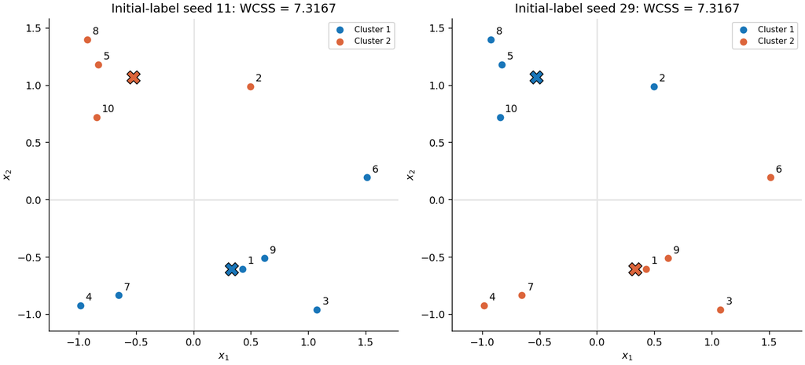

Final cluster assignments and final means for both runs. The cluster numbers and colors swap between runs.

Both runs produce the **same grouping and WCSS**, despite the swapped cluster numbers. The two groups are observations **1, 3, 4, 6, 7, 9** and observations **2, 5, 8, 10**. Cluster labels have no intrinsic meaning, so this relabeling is not a difference in the partition. Different initializations can lead to different local minima on other datasets; agreement between these two runs alone does not prove global optimality.

## Question 2: Image color compression

### (a) Image and pixel matrix

I chose the astronaut portrait supplied as `skimage.data.astronaut()`. It shows Eileen Collins and has a useful mix of orange clothing, skin tones, light background, and dark objects for evaluating color compression. The image comes from NASA and is listed as public domain in the [scikit-image dataset documentation](https://scikit-image.org/docs/stable/api/skimage.data.html#skimage.data.astronaut).

The source image is **512 × 512 pixels with 3 RGB channels**. I resized it to **160 × 160 pixels** using Pillow’s Lanczos resampling, satisfying the 200 × 200 limit. The resized original is shown in the first panel below. I reshaped the resized array from **(160, 160, 3)** to **(25,600, 3)**: one observation per pixel and one column per color channel.

```python
original = data.astronaut()
image = np.asarray(Image.fromarray(original).resize(
    (160, 160), resample=Image.Resampling.LANCZOS))
pixels = image.reshape(-1, 3).astype(float)
```

### (b) Compressed images, means, and WCSS

All clustering uses the same **RGB scale from 0 to 255**, without standardizing channels or adding pixel coordinates. For each K, I used five random nonempty initial assignments, with seeds `432110 + 100*K + r` for `r=0,...,4`, and selected the converged fit with the lowest WCSS. All **20 fits converged** within `max_iter=500`. The table identifies each retained seed and its iteration count. Multiple starts reduce initialization sensitivity but do not guarantee the global optimum.

| K | WCSS | MSE/channel | RMSE/channel | Seed | Iterations |
| --- | --- | --- | --- | --- | --- |
| 2 | 146,131,148.361 | 1,902.749 | 43.621 | 432310 | 12 |
| 3 | 70,697,975.314 | 920.547 | 30.341 | 432410 | 10 |
| 5 | 36,458,391.315 | 474.719 | 21.788 | 432612 | 28 |
| 10 | 14,895,510.435 | 193.952 | 13.927 | 433111 | 99 |

Here $\mathrm{MSE/channel}=\mathrm{WCSS}/(25{,}600\times3)$ and $\mathrm{RMSE/channel}=\sqrt{\mathrm{MSE/channel}}$. These quantify reconstruction error on the common 0–255 channel scale. WCSS sums over pixels and all three channels.

The reconstruction replaces each pixel with the exact, unrounded mean of its assigned cluster. For Matplotlib display only, these RGB means are divided by 255. The means in the following table are rounded for readability, while all WCSS values use full precision.

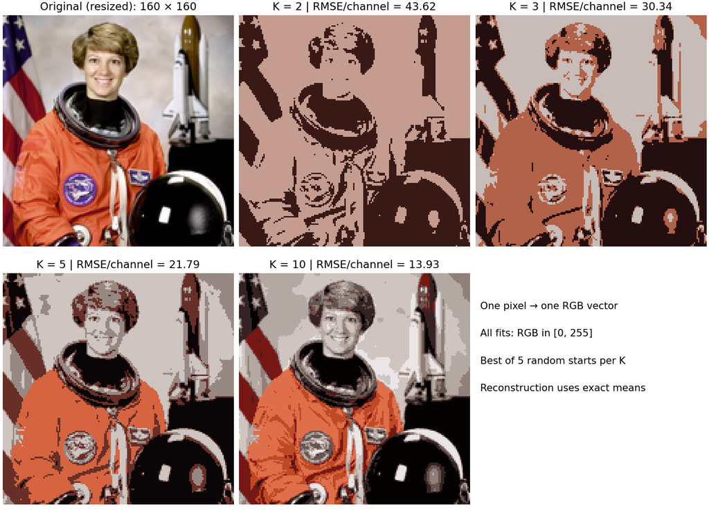

Resized original and reconstructions for K = 2, 3, 5, and 10. All reconstructions use the same RGB scale.

```python
fits = [kmeans(pixels, k, seed=432110 + 100*k + r, max_iter=500)
        for r in range(5)]
best = min(fits, key=lambda fit: fit["wcss"])
reconstructed = best["means"][best["labels"]].reshape(image.shape) / 255
plt.imshow(np.clip(reconstructed, 0, 1))
```

**RGB cluster means and pixel counts for each retained fit:**

| K | Cluster | R | G | B | Pixels |
| --- | --- | --- | --- | --- | --- |
| 2 | 1 | 196.878 | 157.724 | 144.797 | 15547 |
| 2 | 2 | 56.047 | 25.484 | 21.896 | 10053 |
| 3 | 1 | 199.588 | 188.497 | 184.809 | 9494 |
| 3 | 2 | 35.489 | 15.174 | 15.925 | 8030 |
| 3 | 3 | 178.856 | 98.673 | 72.910 | 8076 |
| 5 | 1 | 103.552 | 47.082 | 39.913 | 4150 |
| 5 | 2 | 206.733 | 196.325 | 192.674 | 7664 |
| 5 | 3 | 214.781 | 100.753 | 64.298 | 4508 |
| 5 | 4 | 152.744 | 136.886 | 131.505 | 3820 |
| 5 | 5 | 10.710 | 5.716 | 6.739 | 5458 |
| 10 | 1 | 190.304 | 73.246 | 36.067 | 1736 |
| 10 | 2 | 223.794 | 111.586 | 75.531 | 3097 |
| 10 | 3 | 119.224 | 23.465 | 20.316 | 1630 |
| 10 | 4 | 144.357 | 127.817 | 120.583 | 1870 |
| 10 | 5 | 53.287 | 35.987 | 35.701 | 1859 |
| 10 | 6 | 103.030 | 83.341 | 80.526 | 1601 |
| 10 | 7 | 5.505 | 2.566 | 2.402 | 4621 |
| 10 | 8 | 208.026 | 196.896 | 192.614 | 4223 |
| 10 | 9 | 234.879 | 229.355 | 230.720 | 1310 |
| 10 | 10 | 180.929 | 168.132 | 162.633 | 3653 |

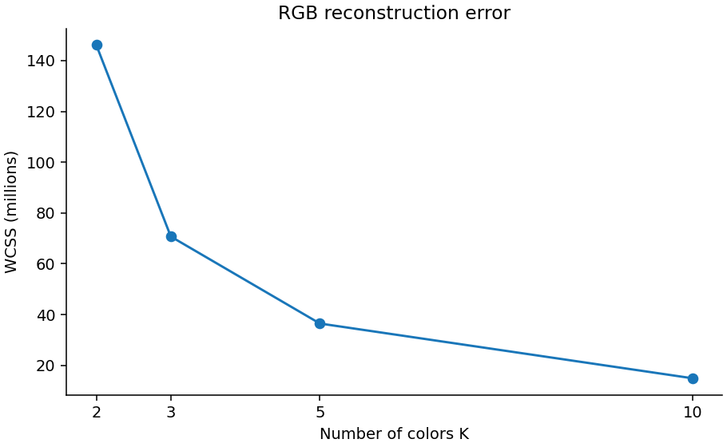

Within-cluster sum of squares for the four tested palette sizes.

### (c) Choice of K

I would choose **K = 10** among the tested values. At K = 2, the portrait is recognizable mainly as a silhouette and loses the separation between the orange suit and pale background. K = 3 restores the orange suit; K = 5 adds facial and background shading, but large flat color regions remain. K = 10 gives a clearer face, better hair and background shading, and more detail around the suit and helmet.

The WCSS falls from **36,458,391** at K = 5 to **14,895,510** at K = 10, a **59.1% reduction**. RMSE per channel decreases from **21.79 to 13.93**. Thus ten colors retain noticeably more detail while still using a small palette. Five colors would also be reasonable if minimizing the palette size were the main priority. This choice concerns visual quality and palette size; no compressed file-size ratio is claimed.

## Question 3: Hierarchical clustering of cars

### (a) Standardization and linkage comparison

I used all **32 cars and 11 numerical variables**. The `car` column is used only for observation labels. For each numerical variable, I subtracted its sample mean and divided by its sample standard deviation (`ddof=1`), giving mean 0 and sample standard deviation 1.

$$z_{ij}=\frac{x_{ij}-\overline{x}_j}{s_j},
\qquad
s_j=\sqrt{\frac{1}{31}\sum_{i=1}^{32}(x_{ij}-\overline{x}_j)^2}.$$

```python
cars = pd.read_csv("data/mtcars.csv").set_index("car")
z = (cars - cars.mean()) / cars.std(ddof=1)
trees = {method: linkage(z.to_numpy(), method=method, metric="euclidean")
         for method in ["single", "complete", "average"]}
```

Single linkage measures distance between two clusters by their closest pair of observations, complete linkage uses the farthest pair, and average linkage averages all between-cluster pairwise distances. The three dendrograms show the same standardized data under these different definitions.

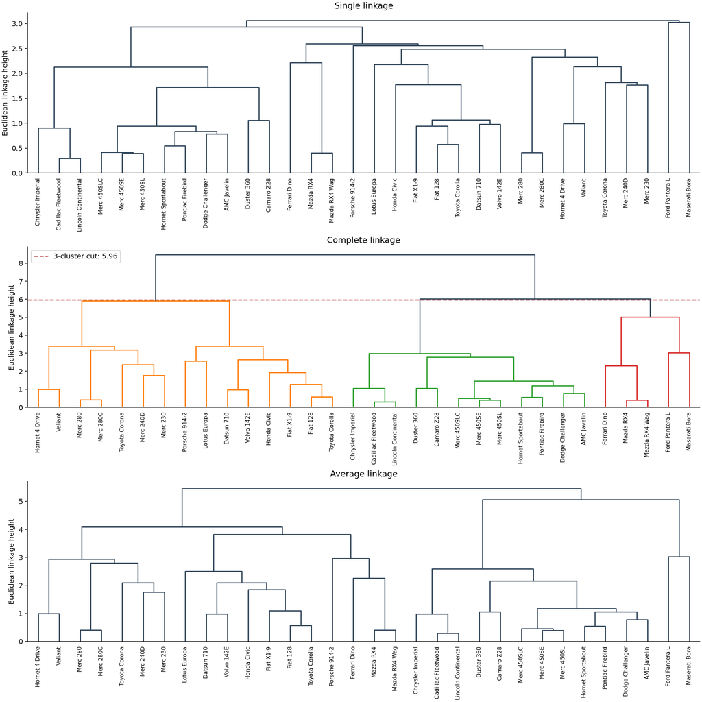

Single, complete, and average linkage dendrograms, with all car names. Heights represent linkage distances, not a common measure of within-cluster variation. The dashed line marks the chosen complete-linkage cut.

**Comparison.** Single linkage displays chaining: several individual cars or small groups attach to a growing branch at relatively similar heights near the top of the tree. For example, Ford Pantera L and Maserati Bora join only near the final merges. Complete linkage creates more clearly separated broad branches and discourages clusters with a large pairwise diameter. Average linkage is intermediate: it retains broad car-type distinctions while being less driven by the farthest pair than complete linkage. The Mazda RX4 pair and the Fiat 128/Toyota Corolla pair merge early under all three methods, indicating strong local similarity. The higher-level groupings differ; for example, Ferrari Dino stays with the Mazda pair on the low-power side of the average-linkage tree but belongs to the separate manual-transmission performance group in the selected complete-linkage partition. Linkage heights differ by definition and should not be compared as if one method had a better objective simply because its final height is smaller.

### (b) Selected clusters and interpretation

I selected **complete linkage with three clusters**, cutting at height **5.9613**, between the merges at **5.9049** (four clusters become three) and **6.0178** (three become two). This separates an economical, generally lighter group; a heavy eight-cylinder automatic group; and a smaller manual-transmission performance group. The third group is useful for describing cars that would otherwise be merged with the heavy automatics.

The interval supporting this three-cluster cut is narrow. The larger jump to the final merge at **8.4802** also supports a coarser two-cluster summary. I chose three for its interpretable differences in weight and transmission, rather than claiming that the dendrogram uniquely determines three clusters.

**Cluster memberships:**

- **Cluster 1 (n = 15):** Datsun 710; Hornet 4 Drive; Valiant; Merc 240D; Merc 230; Merc 280; Merc 280C; Fiat 128; Honda Civic; Toyota Corolla; Toyota Corona; Fiat X1-9; Porsche 914-2; Lotus Europa; Volvo 142E.
- **Cluster 2 (n = 12):** Hornet Sportabout; Duster 360; Merc 450SE; Merc 450SL; Merc 450SLC; Cadillac Fleetwood; Lincoln Continental; Chrysler Imperial; Dodge Challenger; AMC Javelin; Camaro Z28; Pontiac Firebird.
- **Cluster 3 (n = 5):** Mazda RX4; Mazda RX4 Wag; Ford Pantera L; Ferrari Dino; Maserati Bora.

**Cluster means on the original scales:**

The table is split into two panels for readability. `disp` is displacement in cubic inches, `hp` is gross horsepower, `wt` is weight in thousands of pounds, and `qsec` is quarter-mile time in seconds. Means of binary variables `vs` and `am` are proportions; `am=1` denotes manual transmission and `vs=1` denotes a straight engine. Counts and binary indicators are treated as numerical variables, as required by the question.

| Cluster | n | mpg | cyl | disp | hp | wt | qsec |
| --- | --- | --- | --- | --- | --- | --- | --- |
| 1 | 15 | 24.653 | 4.533 | 131.647 | 91.333 | 2.580 | 19.158 |
| 2 | 12 | 15.050 | 8.000 | 357.617 | 194.167 | 4.104 | 17.143 |
| 3 | 5 | 18.500 | 6.800 | 223.400 | 198.800 | 3.001 | 15.616 |

| Cluster | drat | vs | am | gear | carb |
| --- | --- | --- | --- | --- | --- |
| 1 | 3.897 | 0.933 | 0.533 | 3.933 | 1.800 |
| 2 | 3.121 | 0.000 | 0.000 | 3.000 | 3.083 |
| 3 | 3.836 | 0.000 | 1.000 | 4.600 | 5.200 |

- **Cluster 1: relatively economical and lighter cars.** The group averages **24.65 mpg**, **4.53 cylinders**, **91.33 hp**, and **2.58 thousand pounds**. Its mean quarter-mile time is **19.16 seconds**. About **93.3%** have straight engines and **53.3%** have manual transmissions. This is a broad low-power group, including some six-cylinder cars rather than only four-cylinder models.
- **Cluster 2: heavy eight-cylinder automatics.** All 12 cars have **8 cylinders**, automatic transmissions (`am=0`), and three forward gears. Average displacement is **357.62 cubic inches**, weight is **4.10 thousand pounds**, and fuel economy is only **15.05 mpg**. Average horsepower is **194.17**. The group combines high engine output with substantially greater weight.
- **Cluster 3: manual-transmission performance-oriented cars.** All five are manual (`am=1`) and have V-shaped engines (`vs=0`). They average **198.80 hp**, similar to cluster 2, but weigh only **3.00 thousand pounds** and have the fastest average quarter-mile time, **15.62 seconds**. They also average **4.60 gears** and **5.20 carburetors**. The two Mazdas, Ferrari Dino, Ford Pantera L, and Maserati Bora form a mechanically distinct group; the label describes relative group averages and does not imply every member is equally powerful.

**Why standardize?** Euclidean distance depends on units. Without scaling, differences of hundreds in displacement or horsepower would dominate differences of a few units in weight, gear count, or transmission indicators. Standardization gives each variable unit sample variance so that similarity reflects relative differences across all eleven measurements. It does not remove correlations, so related engine-size variables can still collectively influence the clustering. These are descriptive groups, not known ground-truth vehicle classes.

## Reproducibility and checks

The complete analysis source below reproduces the numerical results, CSV tables, and figures. Run `python3 analyze_homework_11.py` from this folder, followed by `python3 render_homework_11.py` and `quarto render homework-11.qmd --to html` to rebuild the report. All numerical work runs in Python; Quarto packages the report as one self-contained HTML file with embedded figures and styles. The original assignment is preserved separately as `homework-11-template.qmd`.

Checks verified that the returned means match the final memberships; the WCSS equals the direct squared-distance sum; the objective never increases; and converged labels select their nearest returned mean. Additional cases covered a cluster becoming empty, five-dimensional data, K = 1, and termination after one iteration. Every image fit converged. I also verified zero means and unit sample standard deviations for the standardized car variables.

**Python environment:**

```json
{
  "python": "3.9.0",
  "numpy": "1.25.2",
  "pandas": "2.0.3",
  "scipy": "1.11.3",
  "matplotlib": "3.8.0",
  "Pillow": "10.0.1",
  "scikit-image": "0.22.0"
}
```

**Complete Python analysis source**

```python
"""Reproduce HW11 numerical results and figures: python3 analyze_homework_11.py."""
from pathlib import Path
import json
import os
import platform

ROOT = Path(__file__).resolve().parent
os.environ.setdefault("MPLCONFIGDIR", str(ROOT / ".mplconfig"))
import matplotlib
matplotlib.use("Agg")
import matplotlib.pyplot as plt
import numpy as np
import pandas as pd
import scipy
import PIL
import skimage
from PIL import Image
from scipy.cluster.hierarchy import linkage, dendrogram, fcluster
from skimage import data


def random_nonempty_labels(n, k, seed):
    """Random labels, with at least one observation in every cluster."""
    if not 1 <= k <= n:
        raise ValueError("Require 1 <= k <= number of observations")
    rng = np.random.default_rng(seed)
    labels = np.r_[np.arange(k), rng.integers(0, k, size=n - k)]
    rng.shuffle(labels)
    return labels


def update_means(x, labels, k, previous=None):
    """Recompute means; an empty cluster retains its previous mean."""
    means = np.empty((k, x.shape[1])) if previous is None else previous.copy()
    for j in range(k):
        members = x[labels == j]
        if len(members):
            means[j] = members.mean(axis=0)
        elif previous is None:
            raise ValueError("Initial assignments must contain every cluster")
    return means


def nearest_labels(x, means):
    # Squared Euclidean distance has the same minimizer as Euclidean distance.
    distances = np.sum((x[:, None, :] - means[None, :, :]) ** 2, axis=2)
    return np.argmin(distances, axis=1)  # Ties go to the lowest cluster index.


def kmeans(x, k, initial_labels=None, seed=0, max_iter=300):
    """Lloyd's algorithm for arbitrary p, implemented without K-means libraries.

    Internally labels are 0,...,k-1. The returned means are recalculated from
    the FINAL labels, even when the iteration limit is reached.
    """
    x = np.asarray(x, dtype=float)
    if x.ndim != 2 or x.shape[0] == 0 or x.shape[1] == 0:
        raise ValueError("x must be a nonempty two-dimensional matrix")
    if not np.isfinite(x).all():
        raise ValueError("x must contain only finite values")
    if not isinstance(k, (int, np.integer)) or not 1 <= k <= len(x):
        raise ValueError("k must be an integer between 1 and n")
    if not isinstance(max_iter, (int, np.integer)) or max_iter < 1:
        raise ValueError("max_iter must be a positive integer")
    if initial_labels is None:
        labels = random_nonempty_labels(len(x), k, seed)
    else:
        labels = np.asarray(initial_labels)
        if (labels.shape != (len(x),)
                or not np.issubdtype(labels.dtype, np.integer)
                or not np.array_equal(np.unique(labels), np.arange(k))):
            raise ValueError("Initial labels must contain exactly 0,...,k-1")
        labels = labels.copy()
    means = update_means(x, labels, k)
    history = [float(np.sum((x - means[labels]) ** 2))]
    converged = False
    for iteration in range(1, max_iter + 1):
        means = update_means(x, labels, k, means)
        updated = nearest_labels(x, means)
        converged = np.array_equal(updated, labels)
        labels = updated
        means = update_means(x, labels, k, means)
        history.append(float(np.sum((x - means[labels]) ** 2)))
        if converged:
            break
    means = update_means(x, labels, k, means)
    return dict(labels=labels, means=means,
                wcss=float(np.sum((x - means[labels]) ** 2)),
                n_iter=iteration, converged=converged, history=history)


def verify_fit(x, fit):
    """Check objective, final means, and descent for every computed fit."""
    labels, means = fit["labels"], fit["means"]
    for j in range(len(means)):
        if np.any(labels == j):
            np.testing.assert_allclose(means[j], x[labels == j].mean(axis=0))
    np.testing.assert_allclose(fit["wcss"], np.sum((x - means[labels]) ** 2))
    assert np.all(np.diff(fit["history"]) <= 1e-6)
    if fit["converged"]:
        np.testing.assert_array_equal(labels, nearest_labels(x, means))


def scatter(ax, x, labels, means, title):
    colors = ["#1976b9", "#dc653b"]
    for j in range(2):
        members = labels == j
        ax.scatter(x[members, 0], x[members, 1], color=colors[j],
                   s=65, label=f"Cluster {j + 1}", edgecolors="white")
        ax.scatter(*means[j], marker="X", s=170, color=colors[j],
                   edgecolors="black", linewidths=0.8)
    for i, (a, b) in enumerate(x):
        ax.annotate(str(i + 1), (a, b), xytext=(5, 5), textcoords="offset points")
    ax.axhline(0, color="0.9", zorder=0)
    ax.axvline(0, color="0.9", zorder=0)
    ax.set(xlabel="$x_1$", ylabel="$x_2$", title=title)
    ax.set_aspect("equal", adjustable="datalim")
    ax.legend(fontsize=8)


def serializable(value):
    if isinstance(value, dict):
        return {str(k): serializable(v) for k, v in value.items()}
    if isinstance(value, (list, tuple)):
        return [serializable(v) for v in value]
    if isinstance(value, np.ndarray):
        return value.tolist()
    if isinstance(value, np.generic):
        return value.item()
    return value


def main():
    plt.rcParams.update({"font.size": 10, "figure.dpi": 140,
                         "axes.spines.top": False, "axes.spines.right": False})
    # Question 1: coordinates and initial assignments use independent seeds.
    x = np.random.default_rng(43211).standard_normal((10, 2))
    initial_a = random_nonempty_labels(10, 2, 11)
    initial_b = random_nonempty_labels(10, 2, 29)
    first_means = update_means(x, initial_a, 2)
    first_labels = nearest_labels(x, first_means)
    a = kmeans(x, 2, initial_labels=initial_a)
    b = kmeans(x, 2, initial_labels=initial_b)
    for fit in [a, b]:
        verify_fit(x, fit)
    q1table = pd.DataFrame({"Observation": np.arange(1, 11),
                           "x1": x[:, 0], "x2": x[:, 1],
                           "Initial A": initial_a + 1,
                           "After one iteration": first_labels + 1,
                           "Final A": a["labels"] + 1,
                           "Initial B": initial_b + 1, "Final B": b["labels"] + 1})
    q1table.to_csv(ROOT / "q1_assignments.csv", index=False)
    fig, ax = plt.subplots(figsize=(7, 5.5), constrained_layout=True)
    scatter(ax, x, first_labels, first_means,
            "One iteration: updated assignments; X = assignment-step means")
    fig.savefig(ROOT / "q1_one_iteration.png")
    plt.close(fig)
    fig, axes = plt.subplots(1, 2, figsize=(11, 5), constrained_layout=True)
    for ax, fit, seed in zip(axes, [a, b], [11, 29]):
        scatter(ax, x, fit["labels"], fit["means"],
                f"Initial-label seed {seed}: WCSS = {fit['wcss']:.4f}")
    fig.savefig(ROOT / "q1_final.png")
    plt.close(fig)
    same = np.array_equal(a["labels"][:, None] == a["labels"][None, :],
                          b["labels"][:, None] == b["labels"][None, :])
```

```python
    # Question 2: scikit-image's bundled NASA photograph; no network required.
    original = data.astronaut()
    image = np.asarray(Image.fromarray(original).resize((160, 160),
                       resample=Image.Resampling.LANCZOS))
    Image.fromarray(image).save(ROOT / "data/astronaut-160.png")
    pixels = image.reshape(-1, 3).astype(float)  # RGB scale 0--255 throughout.
    image_fits = {}
    rows, palettes, restart_rows = [], [], []
    for k in [2, 3, 5, 10]:
        fits = []
        for restart in range(5):
            seed = 432110 + 100 * k + restart
            fit = kmeans(pixels, k, seed=seed, max_iter=500)
            verify_fit(pixels, fit)
            assert fit["converged"], f"Image fit did not converge: K={k}, seed={seed}"
            fits.append(fit)
            restart_rows.append([k, seed, fit["wcss"], fit["n_iter"], fit["converged"]])
        best_index = int(np.argmin([fit["wcss"] for fit in fits]))
        best = fits[best_index]
        best["seed"] = 432110 + 100 * k + best_index
        image_fits[k] = best
        mse = best["wcss"] / pixels.size
        rows.append([k, best["wcss"], mse, np.sqrt(mse), best["seed"], best["n_iter"]])
        counts = np.bincount(best["labels"], minlength=k)
        for j, mean in enumerate(best["means"]):
            palettes.append([k, j + 1, *mean, counts[j]])
    image_summary = pd.DataFrame(rows, columns=["K", "WCSS", "MSE/channel", "RMSE/channel", "Seed", "Iterations"])
    image_summary.to_csv(ROOT / "q2_summary.csv", index=False)
    pd.DataFrame(palettes, columns=["K", "Cluster", "R", "G", "B", "Pixels"]).to_csv(ROOT / "q2_palettes.csv", index=False)
    pd.DataFrame(restart_rows, columns=["K", "Seed", "WCSS", "Iterations", "Converged"]).to_csv(ROOT / "q2_restarts.csv", index=False)
    fig, axes = plt.subplots(2, 3, figsize=(11, 8), constrained_layout=True)
    axes[0, 0].imshow(image)
    axes[0, 0].set_title("Original (resized): 160 × 160")
    for ax, k in zip(axes.flat[1:5], [2, 3, 5, 10]):
        fit = image_fits[k]
        reconstructed = fit["means"][fit["labels"]].reshape(image.shape) / 255
        ax.imshow(np.clip(reconstructed, 0, 1))
        ax.set_title(f"K = {k} | RMSE/channel = {np.sqrt(fit['wcss']/pixels.size):.2f}")
    for ax in axes.flat:
        ax.axis("off")
    axes[1, 2].text(0.02, 0.85, "One pixel → one RGB vector\n\nAll fits: RGB in [0, 255]\n\nBest of 5 random starts per K\n\nReconstruction uses exact means",
                    va="top", fontsize=11, transform=axes[1, 2].transAxes, linespacing=1.6)
    fig.savefig(ROOT / "q2_compression.png")
    plt.close(fig)
    fig, ax = plt.subplots(figsize=(6.5, 4), constrained_layout=True)
    ax.plot(image_summary["K"], image_summary["WCSS"] / 1e6, "o-", color="#1976b9")
    ax.set(xlabel="Number of colors K", ylabel="WCSS (millions)", xticks=[2, 3, 5, 10],
           title="RGB reconstruction error")
    fig.savefig(ROOT / "q2_wcss.png")
    plt.close(fig)

    # Question 3: car is used only as an observation label.
    cars = pd.read_csv(ROOT / "data/mtcars.csv").set_index("car")
    z = (cars - cars.mean()) / cars.std(ddof=1)
    np.testing.assert_allclose(z.mean(), 0, atol=1e-14)
    np.testing.assert_allclose(z.std(ddof=1), 1)
    methods = ["single", "complete", "average"]
    trees = {method: linkage(z.to_numpy(), method=method, metric="euclidean")
             for method in methods}
    selected = trees["complete"]
    cut_height = float((selected[-3, 2] + selected[-2, 2]) / 2)
    groups = fcluster(selected, t=3, criterion="maxclust")
    membership = pd.DataFrame({"Car": cars.index, "Cluster": groups})
    membership.to_csv(ROOT / "q3_membership.csv", index=False)
    means = cars.assign(Cluster=groups).groupby("Cluster").mean()
    means.insert(0, "n", pd.Series(groups).value_counts().sort_index().to_numpy())
    means.to_csv(ROOT / "q3_cluster_means.csv")
    z.to_csv(ROOT / "q3_standardized.csv")
    fig, axes = plt.subplots(3, 1, figsize=(14, 14), constrained_layout=True)
    for ax, method in zip(axes, methods):
        dendrogram(trees[method], labels=cars.index.tolist(), ax=ax,
                   leaf_rotation=90, leaf_font_size=8,
                   color_threshold=cut_height if method == "complete" else 0,
                   above_threshold_color="#34495e")
        ax.set(title=f"{method.capitalize()} linkage", ylabel="Euclidean linkage height")
        if method == "complete":
            ax.axhline(cut_height, color="#b12f32", ls="--", label=f"3-cluster cut: {cut_height:.2f}")
            ax.legend(loc="upper left")
    fig.savefig(ROOT / "q3_dendrograms.png")
    plt.close(fig)
    # Substantive edge cases: empty clusters, p > 2, and early termination.
    edge = np.array([[0.0], [0.0], [10.0]])
    empty_fit = kmeans(edge, 3, initial_labels=np.array([0, 1, 2]))
    verify_fit(edge, empty_fit)
    assert not np.any(empty_fit["labels"] == 1)
    np.testing.assert_allclose(empty_fit["means"][1], [0.0])
    high_dim = np.random.default_rng(123).normal(size=(25, 5))
    verify_fit(high_dim, kmeans(high_dim, 4, seed=123))
    verify_fit(x, kmeans(x, 2, initial_labels=initial_a, max_iter=1))
    verify_fit(x, kmeans(x, 1, seed=1))
    result = dict(q1=dict(data_seed=43211, x=x, initial_a=initial_a,
                         initial_b=initial_b, first_means=first_means,
                         first_labels=first_labels, a=a, b=b, same_grouping=same),
                  q2=dict(original_shape=original.shape, shape=image.shape,
                          matrix_shape=pixels.shape,
                          fits={k: {key: value for key, value in fit.items()
                                    if key != "labels"} for k, fit in image_fits.items()}),
                  q3=dict(cut_height=cut_height,
                          final_merges={m: t[-5:, 2] for m, t in trees.items()}),
                  verification="Objective, means, descent, convergence, empty cluster, p=5, K=1, and max_iter checks passed")
    (ROOT / "results.json").write_text(json.dumps(serializable(result), indent=2) + "\n")
    environment = {"python": platform.python_version(), "numpy": np.__version__,
                   "pandas": pd.__version__, "scipy": scipy.__version__,
                   "matplotlib": matplotlib.__version__, "Pillow": PIL.__version__,
                   "scikit-image": skimage.__version__}
    (ROOT / "environment.json").write_text(json.dumps(environment, indent=2) + "\n")
    (ROOT / "requirements.txt").write_text("\n".join(f"{key}=={value}" for key, value in environment.items() if key != "python") + "\n")
    print(json.dumps(serializable(result), indent=2))
    print(image_summary.to_string(index=False))
    print(means.to_string())
    print(membership.to_string(index=False))
```

```python
if __name__ == "__main__":
    main()
```